# Echantillonnage temporel chiros

Thibaut Couturier

Analyse en date du 2024-01-12

# Importation, préparation des données

# Reconstitution tableau données ; exemple du Murin de Daubenton sur 20 ans

## Modèle jags pour estimer tendances

Sur la base des tirages de site réalisés après application des filtres, nous avons tiré 100 sites avec pondération par leur taille, puis lancé un modèle d’estimation des taux de croissance.

## Reconstitution du jeu de données

A partir des effectifs prédits sur chaque site/année obtenus à partir de ce modèle (médiane des postérieurs), nous avons récupéré la différence entre ces effectifs prédits et ceux observés (comptages réels) afin de calculer une variance “résiduelle” moyenne sur chaque site. A partir de cette variance estimée et de la prédiction moyenne de chaque site/année, nous avons tiré des valeurs dans une loi lognormale. Le choix de cette loi de distribution permettait de ne pas tirer des valeurs en des-sous de zéro, comme cela aurait été le cas avec une loi normale. Ces valeurs estimées nous ont servi à reconstituer les données manquantes dans les séries temporelles. Nous avons conservé les comptages réels lorsqu’ils existaient.

Exemple d’un site hivernal à Murin de Daubenton. La courbe représente la tendance estimée d’après le mo-dèle (avec intervalle de crédibilité en ombré) ; Les points rouges correspondent aux comptages réels et les points verts à des comptages tirés dans une loi lognormale.

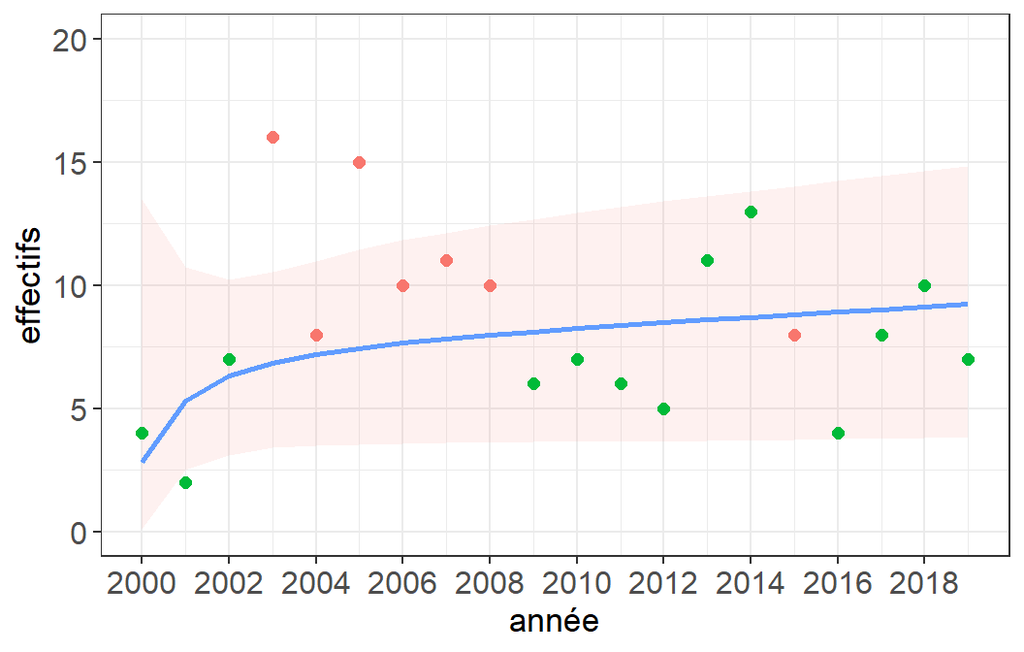

# Echantillonnage temporel

Pour chaque espèce, on obtient un tableau intégrant les données réelles, complété par les valeurs prédites sur 100 sites et sur 20 années.

Exemple de tableau de données pour le murin de Daubenton : 10 premiers sites

| CD_SITE | 2000 | 2001 | 2002 | 2003 | 2004 | 2005 | 2006 | 2007 | 2008 | 2009 | 2010 | 2011 | 2012 | 2013 | 2014 | 2015 | 2016 | 2017 | 2018 | 2019 | mean | mean_log |
| --- | --- | --- | --- | --- | --- | --- | --- | --- | --- | --- | --- | --- | --- | --- | --- | --- | --- | --- | --- | --- | --- | --- |
| 89260.004 | 72 | 66 | 84 | 66 | 102 | 90 | 80 | 77 | 47 | 73 | 46 | 50 | 51 | 80 | 84 | 47 | 50 | 62 | 71 | 72 | 65.333 | 4.1947 |
| 89084.002 | 9 | 21 | 44 | 9 | 39 | 42 | 56 | 89 | 73 | 70 | 74 | 46 | 54 | 51 | 45 | 48 | 27 | 31 | 28 | 51 | 52.333 | 3.9766 |
| 89255.003 | 10 | 6 | 18 | 27 | 27 | 26 | 41 | 28 | 16 | 10 | 15 | 12 | 27 | 21 | 33 | 22 | 16 | 5 | 8 | 13 | 19.533 | 3.0221 |
| 89405.002 | 6 | 7 | 11 | 8 | 11 | 8 | 5 | 4 | 7 | 7 | 4 | 3 | 4 | 12 | 93 | 52 | 17 | 31 | 18 | 14 | 18.600 | 2.9755 |
| 21013.001 | 26 | 33 | 37 | 28 | 42 | 18 | 45 | 28 | 20 | 11 | 17 | 16 | 15 | 1 | 18 | 18 | 16 | 18 | 9 | 23 | 18.200 | 2.9549 |
| 89255.004 | 0 | 9 | 9 | 10 | 10 | 8 | 16 | 16 | 10 | 7 | 6 | 5 | 9 | 9 | 17 | 18 | 16 | 52 | 38 | 40 | 17.800 | 2.9339 |
| 89125.003 | 32 | 17 | 22 | 20 | 8 | 15 | 12 | 20 | 13 | 10 | 18 | 17 | 12 | 14 | 10 | 18 | 40 | 18 | 20 | 15 | 16.800 | 2.8792 |
| 89483.001 | 28 | 48 | 21 | 5 | 9 | 15 | 14 | 47 | 19 | 4 | 3 | 3 | 7 | 11 | 19 | 14 | 0 | 34 | 52 | 6 | 16.533 | 2.8641 |
| 89252.002 | 34 | 14 | 21 | 10 | 17 | 13 | 13 | 17 | 16 | 13 | 8 | 5 | 12 | 13 | 27 | 20 | 20 | 13 | 14 | 11 | 14.333 | 2.7300 |
| 71416.001 | 2 | 2 | 7 | 8 | 16 | 17 | 30 | 17 | 13 | 16 | 16 | 13 | 18 | 4 | 8 | 9 | 8 | 13 | 10 | 11 | 13.533 | 2.6764 |

On teste deux tirages : on sélectionne une année sur deux (donc deux tirages testés, en commençant par 2005, ou en commençant par 2006) puis une année sur trois (trois tirages testés). Des tests préalables en remplaçant les valeurs non tirées par des valeurs manquantes (NA) ne fonctionnaient pas en raison d’une forte structuration des NA dans les jeux de données obtenus. Nous avons donc utilisé la solution de supprimer les colonnes des années non tirées, puis appliqué un correctif sur les tendances (racine carrée de lambda si une année sur deux, racine cubique de lambda si une année sur trois). Pour chaque espèce, on relance le modèle jags sur chacun des six jeux de données (incluant le jeu de données complet, sans ré-échantillonnage).

# Récupération résultats cluster toutes espèces

## Barbastelle

## Murin de beschtein

## Murin de daubenton

## Murin à oreilles échancrées

## Grand murin

## Murin de Natterer

## Grand rhinolophe

## Petit rhinolophe

## Complexe murins

# Graphes et interprétations

## Taux de croissance estimés selon les modalités d’échantillonnage temporel

On enregistre de fortes différences entre les espèces en termes de précision et de biais sur le taux de croissance lambda. Nous avons classé les espèces selon la précision des lambda obtenue : Au début les espèces avec mauvaise précision, à la fin les espèces dont la précision est très bonne.

**Graphes A,B** : passer à une année sur deux diminue la précision, et gros biais selon quelle année on sélectionne pour le A.  
**Graphe C** : ok si une année sur deux, forte imprécision une année sur trois pour un des tirages (mais pas trop biaisé).  
**Graphe D** : précis une année sur deux (mais un peu biaisé), forte imprécision une année sur trois.  
**Graphe E** : Forts biais selon les tirages (même une année sur deux), précision reste bonne.  
**Graphes F, G** : On reste précis et pas trop biaisés une année sur deux (F un peu biaisé), biaisé pour un tirage d’une année sur trois. **Graphes H, I** : On reste précis et pas trop biaisés, même avec une année sur trois.

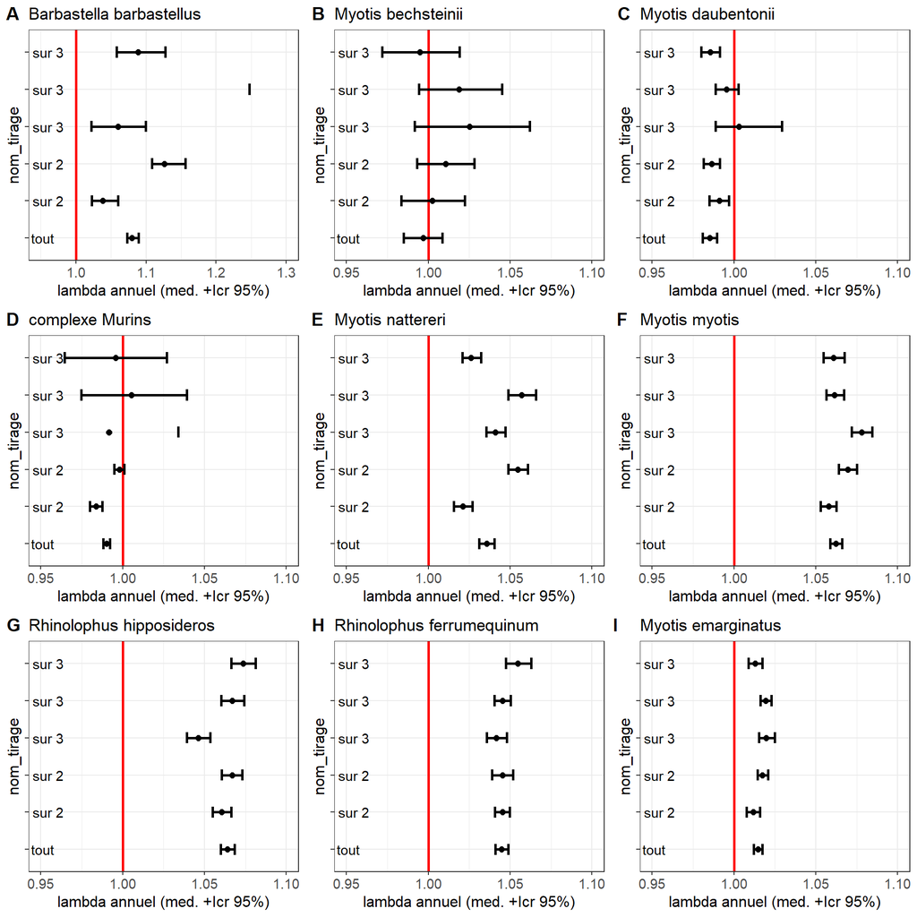

Plusieurs hypothèses pour expliquer une faible précision pour certaines espèces : De fortes variances moyennes de comptages entre sites, des abondances trop faibles, et/ou des variations importantes d’abondance sur les gros sites.

## Variance moyenne inter-sites

On voit que les espèces à très forte variance ne sont pas celles pour lesquelles on obtient une faible précision ou biais (excepté petit Rhinolophe qui est assez biaisé selon les tirages).

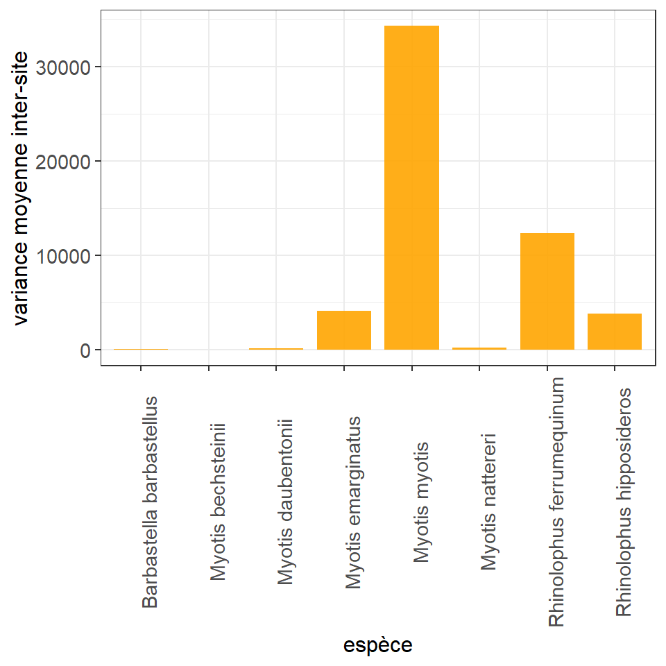

## Fréquence des comptages “réels” sur les 100 sites sélectionnés pour l’analyse

Les espèces avec faible précision de lambda sont celles dont les comptages dépassent rarement 10-20 individus par site (A, B notamment). Les espèces avec précision élevée de lambda sont celles pour lesquelles on a plein de comptages de quelques centaines d’individus (F à H).

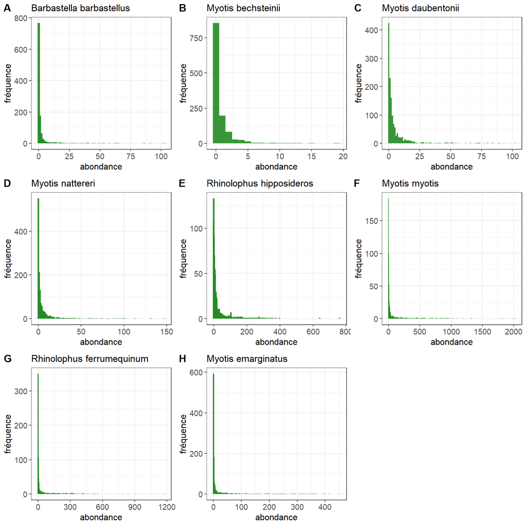

## Comptages obtenus sur les plus gros sites pour les espèces à forte variance taux de croissance

Les espèces à faible précision de lambda correspondent à celles pour lesquelles on enregistre de fortes variations d’abondance sur les plus gros sites (et qui ont par ailleurs des effectifs assez faibles) : Notamment barbastelle et Murin de Beschstein.

### Barbastelle

Sites à plus de 10 individus en moyenne sur la période :

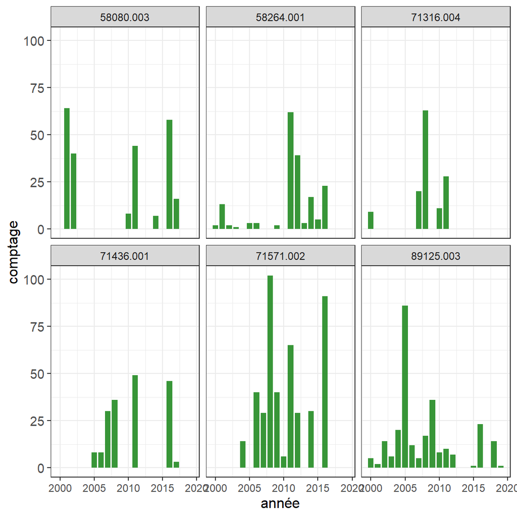

Note : 6 valeurs à 0 et 55 NA.

### Murin de Beschstein

Sites à plus de 2,5 individus en moyenne sur la période :

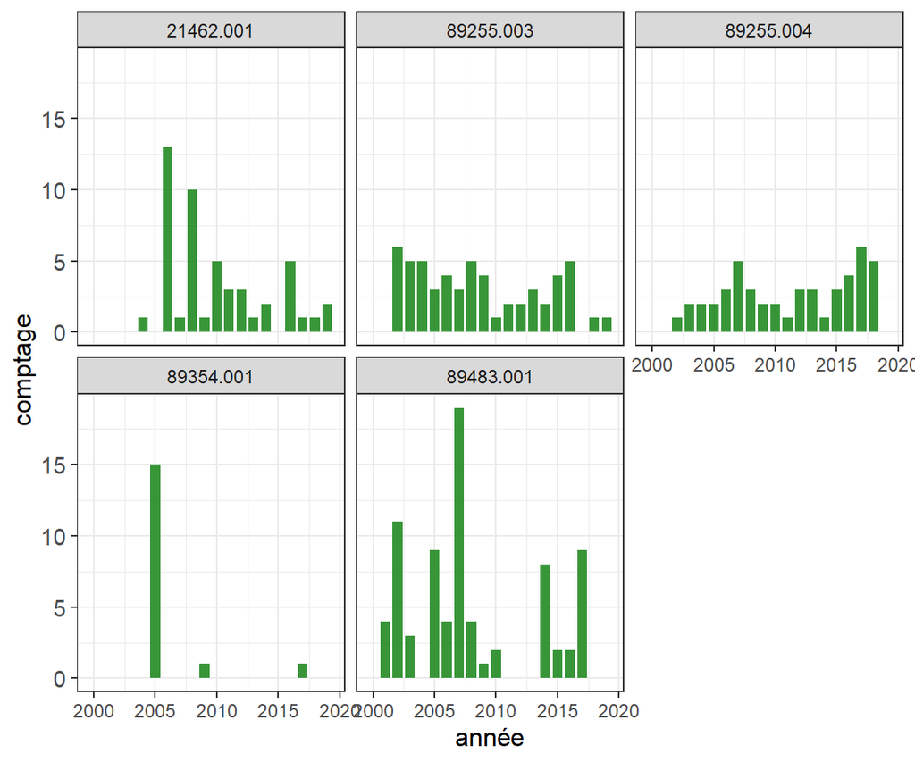

Note : 12 valeurs à 0 et 24 NA.

### Murin de Daubenton

Sites à plus de 15 individus en moyenne sur la période :

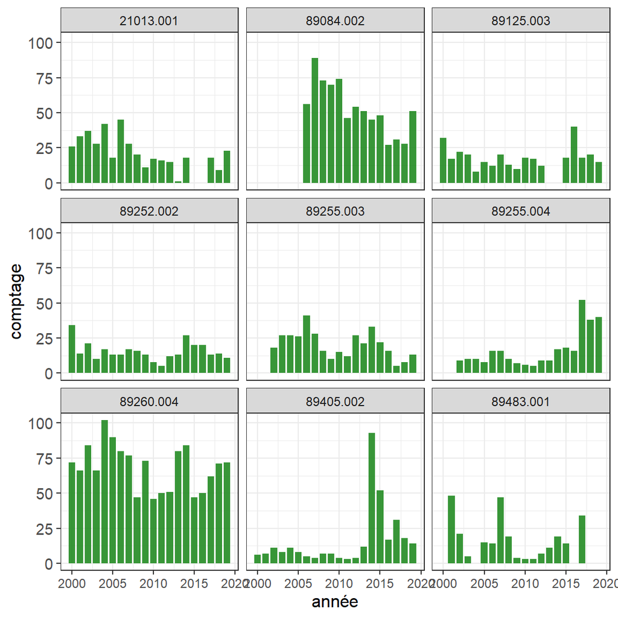

Note : 1 valeurs à 0 et 18 NA.

Ici, pour comparaison, on prend une espèce dont la précision de lambda est très élevée :

#### Murin à oreilles échancrées

Sites à plus de 100 individus en moyenne sur la période :

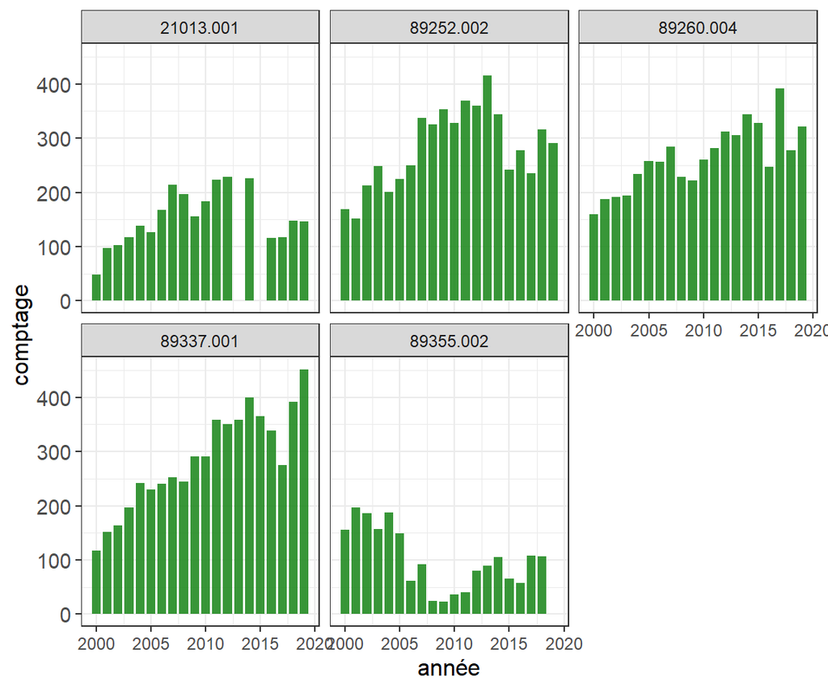

Note : 1 valeurs à 0 et 2 NA.